## © MSU, dep. CS, Statistical Laboratory. Yu.Balasanov,A.Doynikov,M. Tselishchev,

# Снижение размерности с помощью нейронных сетей.

# Autoencoder.

Здесь мы решим задачу снижения размерности с помощью аппарата нейронных сетей, который получил наименование autoencoder. Автоэнкодеры — это искусственные нейронные сети, которые позволяют построить так называемые коды. Коды обычно имеют меньшую размерность, чем входные данные. Это делает их популярным методом уменьшения размерности Автоэнкодеры могут помочь предварительно обучить нижние уровни глубоких нейронных сетей. сети, особенно когда данные имеют ограниченное количество меток Автоэнкодеры можно использовать как генеративные модели, т. е. они могут генерировать новые данные, аналогичные обучающим данным. Наконец, автоэнкодеры стали популярным методом обнаружения аномалий. Автоэнкодер состоит из 2 частей:

- Кодер (сеть распознавания) преобразует входные данные во внутренний представление
- Декодер (генеративная сеть) преобразует внутреннее представление в выходы

Поскольку автоэнкодер тренируется, делая выходные данные равными входным, количество входы и выходы должны быть равны Выходы автоэнкодера также называются реконструкциями или потерями. Автоэнкодер обычно неполный, т.е. внутреннее представление имеет меньшую размерность, чем входы. Это предотвращает тривиальные решения, когда входы просто копируются в выходы Автоэнкодер может быть неполным по-разному:

- Слой внутренних представлений меньше, чем количество входов
- Внутренний слой представления имеет много узлов, но меньшее количество соединений между узлами (разреженный автоэнкодер)

У автоэнкодера есть как кодировщик, так и декодер, содержащий несколько слоев нейронов называется многоуровневым автоэнкодером или глубоким автоэнкодером. Обычно стекированные автоэнкодеры имеют одинаковые размеры слоев, которые симметрично расположены относительно самого узкого места. Кроме того, веса слоя декодирования часто равны транспонированному веса симметричного ему слоя кодирования. Это называется завязывать веса. Связывание весов уменьшает количество весов в сети и ускоряет обучение. Мотивация за дополнительными слоями такая же, как и за глубокими нейронными. сети: более сложный предмет для изучения с меньшим числом параметров. Однако добавление слишком большого количества слоев может привести к тривиальным решениям или потере эффективности из-за недостаточной полноты

### Реализация автоэнкодера

Посмотрим реализацию автоэнкодера на том же примере - кривой доходностей или временной структуре доходностей или англ. Yield Curve Rates. Время до истечения контракта меняется обычно от 0 до 30 лет.

Для сравнения с PCA попутно повторим анализ методом главных компонент.

Читаем данные

```python
%matplotlib inline
import matplotlib.pyplot as plt
import numpy as np
import pandas as pd

RatesData = pd.read_csv("Rates.csv", index_col="Date").iloc[:,:12]
RatesData.head()
```

| Date | 1 Mo | 2 Mo | 3 Mo | 6 Mo | 1 Yr | 2 Yr | 3 Yr | 5 Yr | 7 Yr | 10 Yr | 20 Yr |
| --- | --- | --- | --- | --- | --- | --- | --- | --- | --- | --- | --- |
| 01/03/22 | 0.05 | 0.06 | 0.08 | 0.22 | 0.40 | 0.78 | 1.04 | 1.37 | 1.55 | 1.63 | 2.05 |
| 01/04/22 | 0.06 | 0.05 | 0.08 | 0.22 | 0.38 | 0.77 | 1.02 | 1.37 | 1.57 | 1.66 | 2.10 |
| 01/05/22 | 0.05 | 0.06 | 0.09 | 0.22 | 0.41 | 0.83 | 1.10 | 1.43 | 1.62 | 1.71 | 2.12 |
| 01/06/22 | 0.04 | 0.05 | 0.10 | 0.23 | 0.45 | 0.88 | 1.15 | 1.47 | 1.66 | 1.73 | 2.12 |
| 01/07/22 | 0.05 | 0.05 | 0.10 | 0.24 | 0.43 | 0.87 | 1.17 | 1.50 | 1.69 | 1.76 | 2.15 |

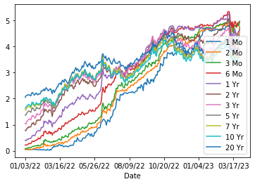

```python
RatesData.plot();
```

Сначала на питоне проведем уже известный нам PCA анализ

```python
from sklearn.decomposition import PCA
from sklearn import linear_model

pca = PCA(svd_solver='full')
pca.fit(RatesData)
print('Explained variance by factors:\n', pca.explained_variance_.round(2))
```

```
Explained variance by factors:
 [17.8   0.61  0.03  0.02  0.    0.    0.    0.    0.    0.    0.  ]
```

Вычислим главные факторы

```python
pca_factors = pd.DataFrame(pca.transform(RatesData),
                           columns=['pca.f{}'.format(i+1) for i in range(pca.n_components_)],
                           index=RatesData.index)
pca_factors.head()
```

| Date | pca.f1 | pca.f2 | pca.f3 | pca.f4 | pca.f5 | pca.f6 | pca.f7 | pca.f8 | pca.f9 | pca.f10 | pca.f11 |
| --- | --- | --- | --- | --- | --- | --- | --- | --- | --- | --- | --- |
| 01/03/22 | 7.123523 | -1.508495 | 0.294807 | -0.086026 | -0.003753 | -0.048536 | 0.021147 | -0.011378 | 0.014009 | 0.011203 | -0.002341 |
| 01/04/22 | 7.122437 | -1.491167 | 0.343461 | -0.119052 | -0.027319 | -0.037238 | 0.027152 | -0.005662 | -0.005019 | 0.009185 | 0.002437 |
| 01/05/22 | 7.044391 | -1.380289 | 0.350180 | -0.090091 | -0.002593 | -0.039031 | 0.016836 | -0.013053 | 0.003860 | 0.001146 | -0.001040 |
| 01/06/22 | 6.989215 | -1.303504 | 0.328079 | -0.065747 | 0.012027 | -0.045905 | 0.008937 | 0.000052 | 0.006351 | 0.004785 | 0.006962 |
| 01/07/22 | 6.966997 | -1.266374 | 0.371806 | -0.081786 | 0.019946 | -0.041604 | 0.030917 | 0.004995 | 0.014163 | 0.001958 | 0.006128 |

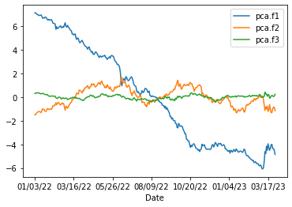

```python
pca_factors[['pca.f1', 'pca.f2','pca.f3']].plot();
```

Возьмем 3 главных компоненты shift,twist,butterfly.

Получим факторные нагрузки

```python
maturities = pd.DataFrame({'maturities':[1/12,2/12,1/4,1/2,1,2,3,5,7,10,20]})
pca_loadings = pd.DataFrame(pca.components_)
pca_loadings = pca_loadings.transpose()
pca_loadings.columns = ['pca.l{}'.format(i+1) for i in range(pca.n_components_)]
pca_loadings = maturities.join(pca_loadings)
pca_loadings
```

|  | maturities | pca.l1 | pca.l2 | pca.l3 | pca.l4 | pca.l5 | pca.l6 | pca.l7 | pca.l8 | pca.l9 | pca.l10 | pca.l11 |
| --- | --- | --- | --- | --- | --- | --- | --- | --- | --- | --- | --- | --- |
| 0 | 0.083333 | -0.401625 | -0.397718 | 0.397441 | 0.455724 | -0.348995 | 0.155722 | 0.261560 | 0.306467 | 0.069840 | -0.028983 | 0.027830 |
| 1 | 0.166667 | -0.409449 | -0.298854 | 0.151204 | -0.014560 | 0.117314 | -0.298695 | -0.062385 | -0.774513 | 0.097007 | 0.032620 | -0.052400 |
| 2 | 0.250000 | -0.409605 | -0.248091 | 0.056572 | -0.252706 | 0.467659 | 0.268460 | -0.536178 | 0.325365 | -0.107832 | 0.077308 | 0.043419 |
| 3 | 0.500000 | -0.396738 | -0.084435 | -0.394072 | -0.445336 | 0.075980 | -0.034069 | 0.648081 | 0.124311 | -0.160077 | -0.110121 | -0.041312 |
| 4 | 1.000000 | -0.348538 | 0.113776 | -0.476972 | 0.005147 | -0.502106 | -0.333020 | -0.393721 | 0.168593 | 0.298845 | 0.040128 | 0.026009 |
| 5 | 2.000000 | -0.264120 | 0.299434 | -0.281988 | 0.467237 | -0.019132 | 0.215452 | -0.067059 | -0.197715 | -0.662963 | 0.112596 | -0.013453 |
| 6 | 3.000000 | -0.222113 | 0.370294 | -0.119702 | 0.255877 | 0.309129 | 0.355400 | 0.082236 | -0.107036 | 0.540581 | -0.440910 | 0.083828 |
| 7 | 5.000000 | -0.180946 | 0.372329 | 0.170112 | 0.070030 | 0.212735 | -0.126007 | 0.163549 | 0.139722 | 0.228920 | 0.630499 | -0.487289 |
| 8 | 7.000000 | -0.165763 | 0.346380 | 0.284990 | -0.028708 | 0.123703 | -0.355573 | 0.097621 | 0.102870 | -0.071910 | 0.131141 | 0.765692 |
| 9 | 10.000000 | -0.155082 | 0.317949 | 0.386002 | -0.113943 | -0.050302 | -0.330279 | -0.124152 | 0.135906 | -0.263816 | -0.582540 | -0.398030 |
| 10 | 20.000000 | -0.145018 | 0.290527 | 0.283164 | -0.476864 | -0.478368 | 0.527518 | -0.047247 | -0.239471 | 0.015116 | 0.131240 | 0.053297 |

Посмотрим на первые три факторные нагрузки, которые как мы знаем называют shift,twist,butterfly.

```
PCA loadings:
     maturities    pca.l1    pca.l2    pca.l3
0     0.083333 -0.401625 -0.397718  0.397441
1     0.166667 -0.409449 -0.298854  0.151204
2     0.250000 -0.409605 -0.248091  0.056572
3     0.500000 -0.396738 -0.084435 -0.394072
4     1.000000 -0.348538  0.113776 -0.476972
5     2.000000 -0.264120  0.299434 -0.281988
6     3.000000 -0.222113  0.370294 -0.119702
7     5.000000 -0.180946  0.372329  0.170112
8     7.000000 -0.165763  0.346380  0.284990
9    10.000000 -0.155082  0.317949  0.386002
10   20.000000 -0.145018  0.290527  0.283164
```

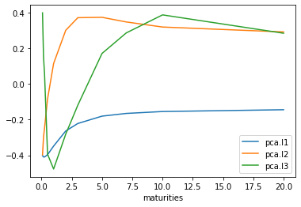

```python
print('PCA loadings: \n',pca_loadings.iloc[:,0:4])
pca_loadings.plot(x='maturities',y=['pca.l1','pca.l2','pca.l3'])
```

Эти же нагрузки можно получить и через линейную регрессионную модель $$y = l*f+\epsilon$$ где $y$- рейты,$f$- PCA факторы $l$- искомые регрессионные коэффициенты нагрузок

```python
regr = linear_model.LinearRegression()

# Train the models for both factors
rf1 = regr.fit(RatesData, pca_factors['pca.f1'])
reg_l1 =pd.DataFrame({'reg.l1': rf1.coef_})

rf2 = regr.fit(RatesData, pca_factors['pca.f2'])
reg_l2 =pd.DataFrame({'reg.l2': rf2.coef_})

rf3 = regr.fit(RatesData, pca_factors['pca.f3'])
reg_l3 =pd.DataFrame({'reg.l3': rf3.coef_})

loadings_by_regression = maturities.join([reg_l1,reg_l2,reg_l3])
print('Loadings by regression: \n',loadings_by_regression)
```

```
Loadings by regression:
     maturities    reg.l1    reg.l2    reg.l3
0     0.083333 -0.401625 -0.397718  0.397441
1     0.166667 -0.409449 -0.298854  0.151204
2     0.250000 -0.409605 -0.248091  0.056572
3     0.500000 -0.396738 -0.084435 -0.394072
4     1.000000 -0.348538  0.113776 -0.476972
5     2.000000 -0.264120  0.299434 -0.281988
6     3.000000 -0.222113  0.370294 -0.119702
7     5.000000 -0.180946  0.372329  0.170112
8     7.000000 -0.165763  0.346380  0.284990
9    10.000000 -0.155082  0.317949  0.386002
10   20.000000 -0.145018  0.290527  0.283164
```

## Автоэнкодер

```python
from tensorflow.keras.layers import Dense, Input
from tensorflow.keras.models import Model
from tensorflow.keras.optimizers import Adam
```

```python
encoding_dim = 3
# encode:
input_layer = Input(shape=(RatesData.shape[1],))
encoded_layer = Dense(encoding_dim, use_bias=False, activation=None)
encoded = encoded_layer(input_layer)

# decode:
input_encoded = Input((encoding_dim,))
decoded_layer = Dense(RatesData.shape[1], use_bias=False, activation=None)
decoded = decoded_layer(input_encoded)

# models:
encoder = Model(input_layer, encoded, name="encoder")
decoder = Model(input_encoded, decoded, name="decoder")
autoencoder = Model(input_layer, decoder(encoder(input_layer)), name="autoencoder")

lr = 0.0005 # learning rate, defaults to 0.001
autoencoder.compile(optimizer=Adam(lr), loss='mse')

autoencoder.summary()
```

```
Model: "autoencoder"
_________________________________________________________________
Layer (type)                 Output Shape              Param #
=================================================================
input_5 (InputLayer)         [(None, 11)]              0
_________________________________________________________________
encoder (Functional)         (None, 3)                 33
_________________________________________________________________
decoder (Functional)         (None, 11)                33
=================================================================
Total params: 66
Trainable params: 66
Non-trainable params: 0
_________________________________________________________________
```

```python
encoding_dim = 3
# encode:
input_layer = Input(shape=(RatesData.shape[1],))
encoded_layer = Dense(encoding_dim, use_bias=False, activation=None)
encoded = encoded_layer(input_layer)

# decode:
input_encoded = Input((encoding_dim,))
decoded_layer = Dense(RatesData.shape[1], use_bias=False, activation=None)
decoded = decoded_layer(input_encoded)

# models:
encoder = Model(input_layer, encoded, name="encoder")
decoder = Model(input_encoded, decoded, name="decoder")
autoencoder = Model(input_layer, decoder(encoder(input_layer)), name="autoencoder")

lr = 0.0005 # learning rate, defaults to 0.001
autoencoder.compile(optimizer=Adam(lr), loss='mse')

autoencoder.summary()
```

```
Model: "autoencoder"
_________________________________________________________________
Layer (type)                 Output Shape              Param #
=================================================================
input_7 (InputLayer)         [(None, 11)]              0
_________________________________________________________________
encoder (Functional)         (None, 3)                 33
_________________________________________________________________
decoder (Functional)         (None, 11)                33
=================================================================
Total params: 66
Trainable params: 66
Non-trainable params: 0
_________________________________________________________________
```

Будем тренировать нашу сеть на нормированных данных

```python
RatesNormalized = (RatesData - RatesData.mean() ) / RatesData.std()
autoencoder.fit(RatesNormalized, RatesNormalized,
                verbose=0,
                epochs=6000,
                batch_size=RatesData.shape[0])
```

```
<tensorflow.python.keras.callbacks.History at 0x20a36d3c760>
```

```python
encoded_rates = pd.DataFrame(encoder.predict(RatesNormalized), index=RatesData.index, columns=['ae.f1', 'ae.f2','ae.f3'])
print(encoded_rates.head())
```

```
             ae.f1     ae.f2     ae.f3
Date
01/03/22 -3.128462  5.160938 -0.596216
01/04/22 -3.175256  5.141011 -0.589281
01/05/22 -3.093974  5.014879 -0.535885
01/06/22 -3.025981  4.938549 -0.484697
01/07/22 -3.036119  4.901502 -0.465326
```

Посмотрим на кодированные 3 фактора

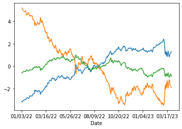

```python
encoded_f1_plot = encoded_rates['ae.f1']
encoded_f2_plot = encoded_rates['ae.f2']
encoded_f3_plot = encoded_rates['ae.f3']
encoded_f1_plot.plot()
encoded_f2_plot.plot()
encoded_f3_plot.plot()
plt.show()
```

Они не очень похожи на те, что дал нам РСА.

Вычислим нагрузки через регрессионную модель

```
Autoencoder loadings by regression:
     maturities   rega.l1   rega.l2   rega.l3
0     0.083333  0.082716 -0.101982 -0.193382
1     0.166667 -0.172253 -0.009857 -0.248210
2     0.250000  0.118082  0.061251 -0.375794
3     0.500000  0.048482  0.019212  0.181743
4     1.000000  0.361539 -0.262459  0.092647
5     2.000000  0.516058 -0.600131  0.144162
6     3.000000  0.342886 -0.417212  0.211074
7     5.000000  0.626323 -0.603417 -0.135727
8     7.000000 -0.594884  0.368691  0.885629
9    10.000000  0.338266 -0.374929 -0.137552
10   20.000000 -0.566899 -0.694535  0.006336
```

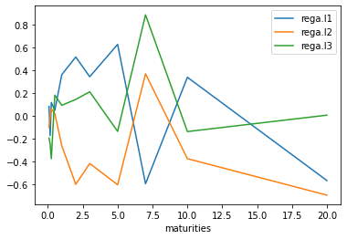

```python
rfa1 = regr.fit(RatesData, encoded_rates['ae.f1'])
rega_l1 =pd.DataFrame({'rega.l1': rfa1.coef_})

rfa2 = regr.fit(RatesData, encoded_rates['ae.f2'])
rega_l2 =pd.DataFrame({'rega.l2': rfa2.coef_})

rfa3 = regr.fit(RatesData, encoded_rates['ae.f3'])
rega_l3 =pd.DataFrame({'rega.l3': rfa3.coef_})

ae_loadings_by_regression = maturities.join([rega_l1,rega_l2,rega_l3])
print('Autoencoder loadings by regression: \n',ae_loadings_by_regression)
ae_loadings_by_regression.plot(x='maturities',y=['rega.l1','rega.l2','rega.l3'])
```

Из теории РСА мы знаем, что главные факторы должны быть некоррелированы. Проверим это

```python
pd.concat([pca_factors, encoded_rates], axis=1).corr().round(2)
```

|  | pca.f1 | pca.f2 | pca.f3 | pca.f4 | pca.f5 | pca.f6 | pca.f7 | pca.f8 | pca.f9 | pca.f10 | pca.f11 | ae.f1 | ae.f2 | ae.f3 |
| --- | --- | --- | --- | --- | --- | --- | --- | --- | --- | --- | --- | --- | --- | --- |
| pca.f1 | 1.00 | -0.00 | -0.00 | 0.00 | 0.00 | -0.00 | -0.00 | 0.00 | -0.0 | -0.0 | -0.00 | -0.99 | 0.97 | 0.37 |
| pca.f2 | -0.00 | 1.00 | 0.00 | 0.00 | -0.00 | 0.00 | 0.00 | 0.00 | -0.0 | 0.0 | 0.00 | 0.14 | -0.24 | 0.93 |
| pca.f3 | -0.00 | 0.00 | 1.00 | -0.00 | -0.00 | -0.00 | -0.00 | -0.00 | -0.0 | -0.0 | -0.00 | -0.05 | -0.00 | -0.05 |
| pca.f4 | 0.00 | 0.00 | -0.00 | 1.00 | -0.00 | -0.00 | 0.00 | -0.00 | -0.0 | -0.0 | -0.00 | 0.05 | -0.01 | 0.01 |
| pca.f5 | 0.00 | -0.00 | -0.00 | -0.00 | 1.00 | -0.00 | 0.00 | -0.00 | 0.0 | -0.0 | -0.00 | 0.01 | 0.01 | -0.00 |
| pca.f6 | -0.00 | 0.00 | -0.00 | -0.00 | -0.00 | 1.00 | 0.00 | -0.00 | 0.0 | -0.0 | -0.00 | -0.00 | -0.01 | -0.02 |
| pca.f7 | -0.00 | 0.00 | -0.00 | 0.00 | 0.00 | 0.00 | 1.00 | 0.00 | 0.0 | 0.0 | 0.00 | -0.00 | 0.00 | 0.03 |
| pca.f8 | 0.00 | 0.00 | -0.00 | -0.00 | -0.00 | -0.00 | 0.00 | 1.00 | -0.0 | -0.0 | -0.00 | 0.01 | 0.00 | 0.00 |
| pca.f9 | -0.00 | -0.00 | -0.00 | -0.00 | 0.00 | 0.00 | 0.00 | -0.00 | 1.0 | 0.0 | -0.00 | 0.00 | -0.00 | -0.00 |
| pca.f10 | -0.00 | 0.00 | -0.00 | -0.00 | -0.00 | -0.00 | 0.00 | -0.00 | 0.0 | 1.0 | -0.00 | -0.00 | -0.00 | -0.00 |
| pca.f11 | -0.00 | 0.00 | -0.00 | -0.00 | -0.00 | -0.00 | 0.00 | -0.00 | -0.0 | -0.0 | 1.00 | -0.00 | 0.00 | 0.01 |
| ae.f1 | -0.99 | 0.14 | -0.05 | 0.05 | 0.01 | -0.00 | -0.00 | 0.01 | 0.0 | -0.0 | -0.00 | 1.00 | -0.99 | -0.23 |
| ae.f2 | 0.97 | -0.24 | -0.00 | -0.01 | 0.01 | -0.01 | 0.00 | 0.00 | -0.0 | -0.0 | 0.00 | -0.99 | 1.00 | 0.13 |
| ae.f3 | 0.37 | 0.93 | -0.05 | 0.01 | -0.00 | -0.02 | 0.03 | 0.00 | -0.0 | -0.0 | 0.01 | -0.23 | 0.13 | 1.00 |

Как мы видим PCA факторы некоррелированы, но факторы от автоэнкодера коррелированы.

Повернем факторы и нагрузки автоэнкодера, использую совственные вектора ковариационной матрицы

```python
encoded_rates.cov() # autoencoder factors covariance
```

|  | ae.f1 | ae.f2 | ae.f3 |
| --- | --- | --- | --- |
| ae.f1 | 2.286799 | -3.665008 | -0.165427 |
| ae.f2 | -3.665008 | 5.966648 | 0.156744 |
| ae.f3 | -0.165427 | 0.156744 | 0.233490 |

Получим собственные вектора ковариационной матрицы

```python
eg_vect_factors = np.linalg.eig(encoded_rates.cov())[1]
eg_vect_factors = pd.DataFrame(eg_vect_factors)
eg_vect_factors # matrix of eigenvectors of covariance matrix
```

|  | 0 | 1 | 2 |
| --- | --- | --- | --- |
| 0 | 0.525011 | -0.825513 | -0.207106 |
| 1 | -0.850651 | -0.501094 | -0.159055 |
| 2 | -0.027522 | -0.259680 | 0.965302 |

Умножим факторы автоэнкодера на эти собственные вектора. Таким образом произведем поворот факторов автоэнкодера

```python
rotated_factors = pd.DataFrame(np.dot(encoded_rates,eg_vect_factors), \
                              columns=['rot.f1','rot.f2','rot.f3'])
rotated_factors.head()
```

|  | rot.f1 | rot.f2 | rot.f3 |
| --- | --- | --- | --- |
| 0 | -6.016221 | 0.151295 | -0.748479 |
| 1 | -6.024029 | 0.198109 | -0.728924 |
| 2 | -5.875530 | 0.180348 | -0.674153 |
| 3 | -5.776311 | 0.149175 | -0.626682 |
| 4 | -5.750653 | 0.171077 | -0.599991 |

Посмотрим на ковариационную матрицу повернутых факторов автоэнкодера

```python
rotated_factors.cov()
```

|  | rot.f1 | rot.f2 | rot.f3 |
| --- | --- | --- | --- |
| rot.f1 | 8.233715e+00 | 1.603895e-15 | 9.197964e-17 |
| rot.f2 | 1.603895e-15 | 1.006598e-02 | 5.090768e-16 |
| rot.f3 | 9.197964e-17 | 5.090768e-16 | 2.431554e-01 |

Как мы видим они стали некоррелированными. Факторы PCA упорялочены по убыванию дисперсии. Но воможно повернутые факторы идут в другом порядке. Поэтому мы посмотрим на корреляцию между PCA факторами и факторами автоэнкодера с помощью следующей функции

```python
def defineOrder(pca_factors,rot_factors):
    pca_cols = pca_factors.columns
    rot_cols = rot_factors.columns
    ncol = len(pca_cols)
    mylist = []
    alllist = []
    i = 0

    for pca_col in pca_cols:
        pcaf =pca_factors[pca_col]
        j = 0
        for rot_col in rot_cols:
            rotf = rot_factors[rot_col]
            cor = np.corrcoef(pcaf,rotf)[0,1]
            print(i,j,abs(cor))
            mylist = []
            mylist.append(i)
            mylist.append(j)
            mylist.append(abs(cor))
            mylist.append(np.sign(cor))
            alllist.append(mylist)
            j = j+1
        i = i +1
    df = pd.DataFrame(alllist,columns = ['col1','col2','value','sign'])
    df = df.sort_values(by=['value'], ascending=False)
    df = df[:ncol]
    df = df.sort_values(by='col1')
    return df
```

Для начала пронормируем PCA факторы и повернутые факторы автоэнкодера

```python
    norm_factors = pd.DataFrame()

    for i in range(3):
        rotated_factors['rot.f'+str(i+1)] = rotated_factors['rot.f'+str(i+1)] / rotated_factors['rot.f'+str(i+1)].std()
        norm_factors['pca.f'+str(i+1)] = pca_factors['pca.f'+str(i+1)] / pca_factors['pca.f'+str(i+1)].std()
```

```python
orderdf= defineOrder(norm_factors, rotated_factors)
orderdf
```

```
0 0 0.9774071653194105
0 1 0.019142842010941755
0 2 0.20934876095415095
1 0 0.20988842097292798
1 1 0.001690947918880915
1 2 0.9767623368951387
2 0 0.011985635024211972
2 1 0.7380222462432751
2 2 0.01151069705861947
```

|  | col1 | col2 | value | sign |
| --- | --- | --- | --- | --- |
| 0 | 0 | 0 | 0.977407 | -1.0 |
| 5 | 1 | 2 | 0.976762 | 1.0 |
| 7 | 2 | 1 | 0.738022 | 1.0 |

Заметим,что 1-му РСА фактору соответствует и 1-й повернутый от автоэнкодера,умноженный на -1, но 2-му РСА фактору соответствует 3-й повернутый от автоэнкодера, а 3-му РСА фактору соответствует 2-й повернутый от автоэнкодера с тем же знаком.

Посмотрим на графики факторов согласно полученному только что соответствию

Первые факторы

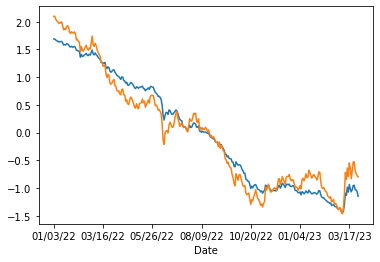

```python
pca_f_plot = pca_factors['pca.f1']/pca_factors['pca.f1'].std()
rot_f_plot = -rotated_factors['rot.f1']/rotated_factors['rot.f1'].std()
pca_f_plot.plot()
rot_f_plot.plot()
plt.show()
```

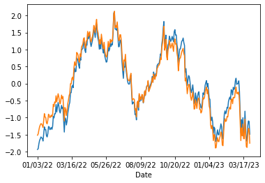

```python
pca_f_plot = pca_factors['pca.f2']/pca_factors['pca.f2'].std()
rot_f_plot = rotated_factors['rot.f3']/rotated_factors['rot.f3'].std()
pca_f_plot.plot()
rot_f_plot.plot()
plt.show()
```

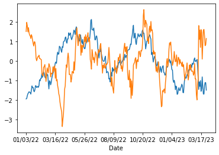

```python
Тpca_f_plot = pca_factors['pca.f3']/pca_factors['pca.f3'].std()
rot_f_plot = rotated_factors['rot.f2']/rotated_factors['rot.f2'].std()
pca_f_plot.plot()
rot_f_plot.plot()
plt.show()
```

```
    maturities    rot.l1    rot.l2    rot.l3
0     0.083333  0.135500  0.033037 -0.187582
1     0.166667 -0.075218  0.211592 -0.202355
2     0.250000  0.020234 -0.030584 -0.396953
3     0.500000  0.004109 -0.096845  0.162340
4     1.000000  0.410523 -0.190997  0.056301
5     2.000000  0.777470 -0.162726  0.127736
6     3.000000  0.529111 -0.128806  0.199096
7     5.000000  0.845859 -0.179423 -0.164756
8     7.000000 -0.650323  0.076355  0.919462
9    10.000000  0.500312 -0.055649 -0.143202
10   20.000000  0.293004  0.814365  0.233994
```

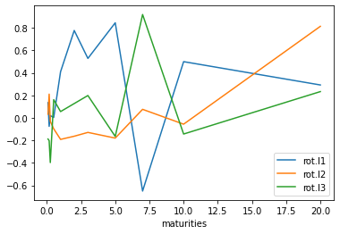

```python
rotated_loadings = pd.DataFrame(np.dot(ae_loadings_by_regression[['rega.l1','rega.l2','rega.l3']], \
                                       eg_vect_factors),columns=['rot.l1','rot.l2','rot.l3'])
rotated_loadings = maturities.join(rotated_loadings)
print(rotated_loadings)
rotated_loadings.plot(x='maturities',y=['rot.l1','rot.l2','rot.l3'])
```

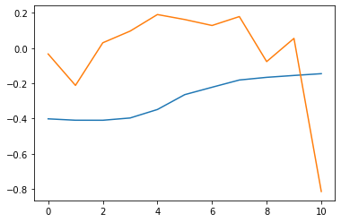

```python
pca_l_plot = pca_loadings['pca.l1']
rot_l_plot = -rotated_loadings['rot.l2']
pca_l_plot.plot(x=maturities)
rot_l_plot.plot(x=maturities)
plt.show()
```

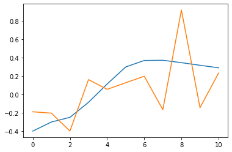

```python
pca_l_plot = pca_loadings['pca.l2']
rot_l_plot = rotated_loadings['rot.l3']
pca_l_plot.plot(x=maturities)
rot_l_plot.plot(x=maturities)
plt.show()
```

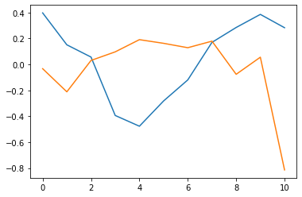

```python
pca_l_plot = pca_loadings['pca.l3']
rot_l_plot = -rotated_loadings['rot.l2']
pca_l_plot.plot(x=maturities)
rot_l_plot.plot(x=maturities)
plt.show()
```

Факторы стали похожи, но нагрузки остались очень различными. Итак мы провели снижение размерности, получили похожие факторы, но получили совсем другое решение для нагрузок